# New York Property Price

Alex

2023-09-15

## Introduction

The data is a subset of condominium sales data from all five boroughs of New York City.

The purpose of this Guided Project is to explore the following questions:

1. How well does the size of a condominium (measured in gross square feet) explain or predict sale price across New York City as a whole?
- To answer this, we’ll explore property sales data for all five boroughs combined.
2. How well does the size of a condominium explain or predict sale price for each individual borough? *For this question, we’ll build, analyze, and compare linear models for each borough.

Along the way, we’ll also see how erroneous sale price entries influence our models, and we will devise methods to remove problematic entries.

## 1. Read data

```r
library(readr)
library(dplyr)
library(purrr)
library(tidyr)
library(ggplot2)
library(caret)
library(broom)

# Read data
ny <- read_csv('NYC_property_sales.csv',  col_types = cols())
head(ny)
```

```
## # A tibble: 6 × 20
##   borough neighborhood building_class_category tax_class_at_present block   lot
##   <chr>   <chr>        <chr>                   <chr>                <dbl> <dbl>
## 1 Bronx   Bathgate     01 One Family Dwellings 1                     3030    62
## 2 Bronx   Bathgate     01 One Family Dwellings 1                     3030    70
## 3 Bronx   Bathgate     01 One Family Dwellings 1                     3039    63
## 4 Bronx   Bathgate     01 One Family Dwellings 1                     3043    55
## 5 Bronx   Bathgate     01 One Family Dwellings 1                     3046    35
## 6 Bronx   Bathgate     01 One Family Dwellings 1                     3046    39
## # ℹ 14 more variables: building_class_at_present <chr>, address <chr>,
## #   apartment_number <chr>, zip_code <dbl>, residential_units <dbl>,
## #   commercial_units <dbl>, total_units <dbl>, land_square_feet <dbl>,
## #   gross_square_feet <dbl>, year_built <dbl>, tax_class_at_time_of_sale <dbl>,
## #   building_class_at_time_of_sale <chr>, sale_price <dbl>, sale_date <dttm>
```

```r
# Data type
map_df(ny, typeof)
```

```
## # A tibble: 1 × 20
##   borough   neighborhood building_class_categ…¹ tax_class_at_present block lot
##   <chr>     <chr>        <chr>                  <chr>                <chr> <chr>
## 1 character character    character              character            doub… doub…
## # ℹ abbreviated name: ¹building_class_category
## # ℹ 14 more variables: building_class_at_present <chr>, address <chr>,
## #   apartment_number <chr>, zip_code <chr>, residential_units <chr>,
## #   commercial_units <chr>, total_units <chr>, land_square_feet <chr>,
## #   gross_square_feet <chr>, year_built <chr>, tax_class_at_time_of_sale <chr>,
## #   building_class_at_time_of_sale <chr>, sale_price <chr>, sale_date <chr>
```

```r
# Missing data
colSums(is.na(ny))
```

```
##                        borough                   neighborhood
##                              0                              0
##        building_class_category           tax_class_at_present
##                              0                              0
##                          block                            lot
##                              0                              0
##      building_class_at_present                        address
##                              0                              0
##               apartment_number                       zip_code
##                          26109                             33
##              residential_units               commercial_units
##                              0                              0
##                    total_units               land_square_feet
##                              0                              0
##              gross_square_feet                     year_built
##                              0                              0
##      tax_class_at_time_of_sale building_class_at_time_of_sale
##                              0                              0
##                     sale_price                      sale_date
##                              0                              0
```

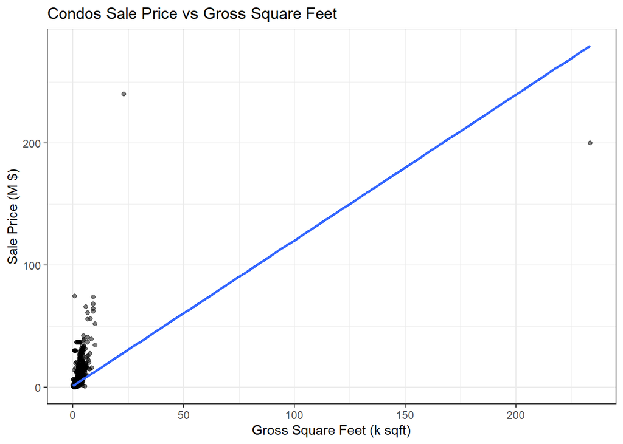

```r
# Using plot, price vs gross square feet

NYC_condos <- ny %>%
  filter(building_class_at_time_of_sale=='R4')

ggplot(data=NYC_condos, aes(x=gross_square_feet/1e3, y=sale_price/1e6)) + geom_point(alpha=0.5) +
  scale_y_continuous(labels=scales::comma)  +
  geom_smooth(method='lm', se=FALSE) +
  theme_bw() +
  labs(title='Condos Sale Price vs Gross Square Feet', x='Gross Square Feet (k sqft)', y= 'Sale Price (M $)')
```

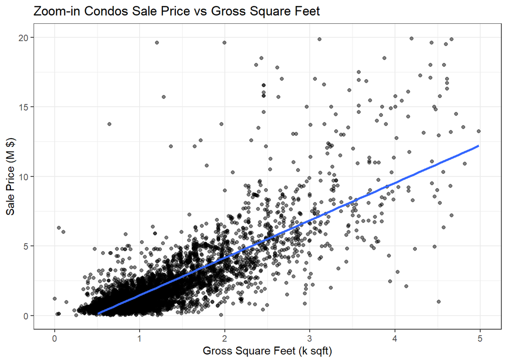

```r
# Zoom-in
ggplot(data=NYC_condos, aes(x=gross_square_feet/1e3, y=sale_price/1e6)) + geom_point(alpha=0.5) +
  scale_y_continuous(labels=scales::comma) +
  xlim(0, 5) +
  ylim(0, 20) +
  geom_smooth(method='lm', se=FALSE) +
  theme_bw() +
  labs(title='Zoom-in Condos Sale Price vs Gross Square Feet', x='Gross Square Feet (k sqft)', y= 'Sale Price (M $)')
```

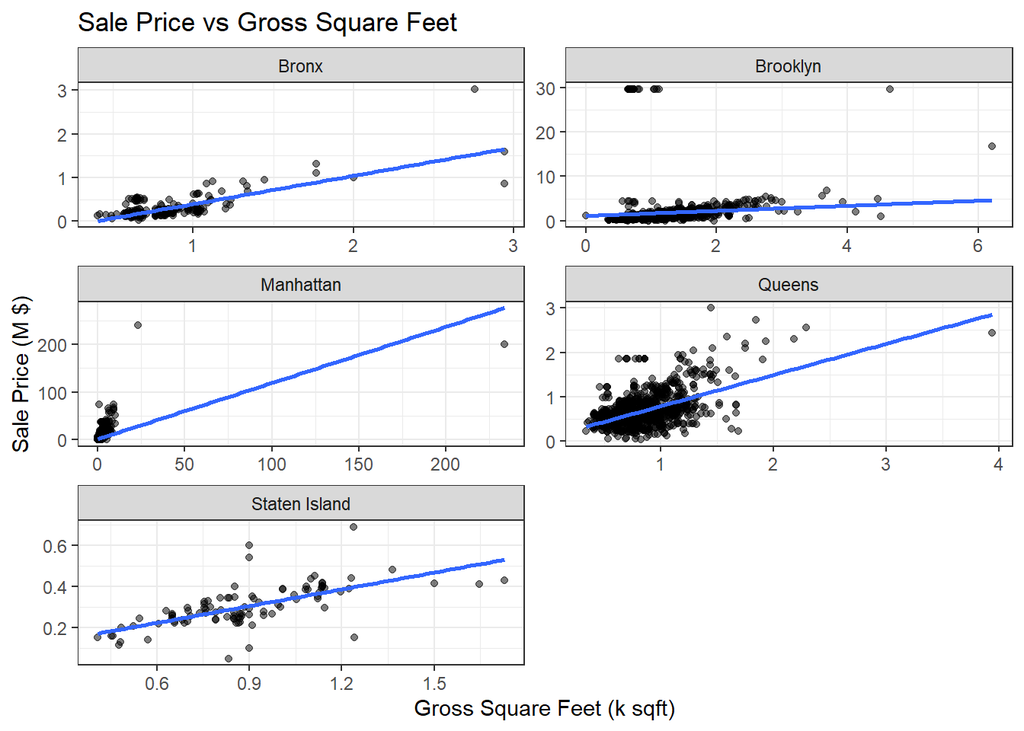

```r
# Facet wrap

ggplot(data=NYC_condos, aes(x=gross_square_feet/1e3, y=sale_price/1e6)) + geom_point(alpha=0.5) +
  scale_y_continuous(labels=scales::comma) +
  geom_smooth(method='lm', se=FALSE) +
  theme_bw() +
  labs(title='Sale Price vs Gross Square Feet', x='Gross Square Feet (k sqft)', y= 'Sale Price (M $)') +
  facet_wrap(vars(borough), ncol=2, scales='free')
```

## 2. Data Cleaning

### 2.1 Check the details of the outlier and decide keep or drop it

```r
# check the price outliers

NYC_condos %>%
  filter(sale_price >100e6) %>%
  select(address, zip_code, gross_square_feet, sale_price, sale_date)
```

```
## # A tibble: 2 × 5
##   address              zip_code gross_square_feet sale_price sale_date
##   <chr>                   <dbl>             <dbl>      <dbl> <dttm>
## 1 220 Central Park So…    10019             23029  239958219 2019-01-23 00:00:00
## 2 165 East 66th St, R…    10065            233578  200000000 2019-04-05 00:00:00
```

1. [240 M property is located in 220 Central Park South](https://www.6sqft.com/billionaire-ken-griffin-buys-238m-nyc-penthouse-the-most-expensive-home-sold-in-the-u-s/]. It is skyscraper. It is composed of two sections: a 70-story, 950-foot (290 m) tower on 58th Street, which is the 21st-tallest building in New York City, as well as an 18-story section on Central Park South, both of which contain a limestone facade. Most of the 118 apartments are duplex apartments, although some of the units have been combined to create larger units. The building has a porte-cochère, a wine cellar, private dining rooms, and various recreational facilities
2. [200 M is the located in 165 East 66th St, Resi](https://therealdeal.com/new-york/2019/04/12/cim-group-acquires-resi-portion-of-ues-luxury-rental-for-200m/). It is a UES luxury rental tower. These two are not commercial properties and should be cleaned.

### 2.2 Duplicated addresses houses

```r
dup_address <- NYC_condos %>%
  filter(duplicated(NYC_condos$address)) %>%
  select(address, sale_price)
```

There are 40 units at 554 4 Avenue, with the same sale_price of 29620207$. It is more likely that the sale price is for 40 unit. The average gross square feet is 843 and sale price per unit is 740505 dollar.

### 2.3 Clean these duplicted address houses

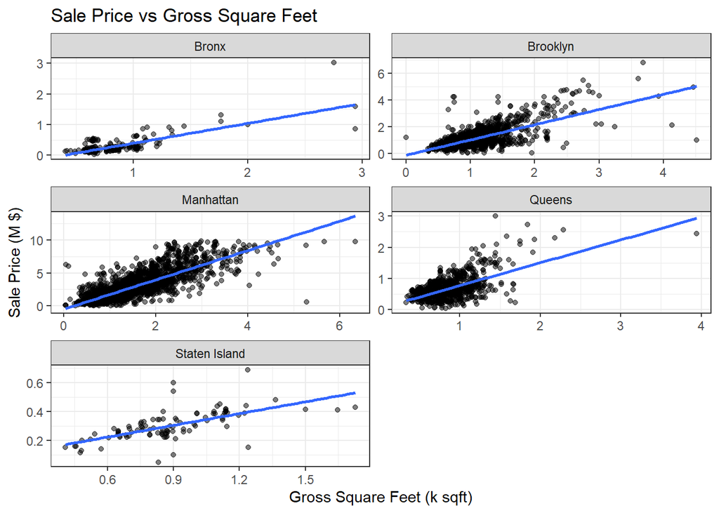

```r
multi_unit_sales <- NYC_condos %>%
  group_by(sale_price, sale_date) %>%
  filter(n()>3) %>%
  arrange(sale_price)

condos_cc <- NYC_condos %>%
  filter(sale_price < 10e6) %>%
  anti_join(multi_unit_sales)


ggplot(data=condos_cc, aes(x=gross_square_feet/1e3, y=sale_price/1e6)) + geom_point(alpha=0.5) +
  scale_y_continuous(labels=scales::comma) +
  geom_smooth(method='lm', se=FALSE) +
  theme_bw() +
  labs(title='Sale Price vs Gross Square Feet', x='Gross Square Feet (k sqft)', y= 'Sale Price (M $)') +
  facet_wrap(vars(borough), ncol=2, scales='free')
```

After cleaning the multiple unit sales, the linear relationship is very prominent.

## 3. Linear model fitting

```r
condos_lm <- lm(sale_price ~ gross_square_feet, data=condos_cc)
condos_lm_org <- lm(sale_price ~ gross_square_feet, data=NYC_condos)

library(tibble)
lm_fit <- summary(condos_lm)
lm_org_fit <- summary(condos_lm_org)
lm_org_fit[2]
```

[output not shown]

```r
lm_org_fit
```

```
##
## Call:
## lm(formula = sale_price ~ gross_square_feet, data = NYC_condos)
##
## Residuals:
##       Min        1Q    Median        3Q       Max
## -79533546  -1211195   -860173   -251714 211550415
##
## Coefficients:
##                    Estimate Std. Error t value Pr(>|t|)
## (Intercept)       940683.39   57703.86   16.30   <2e-16 ***
## gross_square_feet   1192.72      19.43   61.39   <2e-16 ***
## ---
## Signif. codes:  0 '***' 0.001 '**' 0.01 '*' 0.05 '.' 0.1 ' ' 1
##
## Residual standard error: 4745000 on 8094 degrees of freedom
## Multiple R-squared:  0.3177, Adjusted R-squared:  0.3176
## F-statistic:  3769 on 1 and 8094 DF,  p-value: < 2.2e-16
```

```r
lm_org_fit$coefficients [, 1]
```

```
##       (Intercept) gross_square_feet
##        940683.388          1192.719
```

```r
lm_org_fit$coefficients
```

```
##                     Estimate  Std. Error  t value     Pr(>|t|)
## (Intercept)       940683.388 57703.85822 16.30191 8.218631e-59
## gross_square_feet   1192.719    19.42756 61.39314 0.000000e+00
```

```r
# confident interval
confint(condos_lm)
```

```
##                         2.5 %      97.5 %
## (Intercept)       -790662.346 -704186.243
## gross_square_feet    2135.485    2204.743
```

```r
confint(condos_lm_org)
```

```
##                        2.5 %      97.5 %
## (Intercept)       827568.990 1053797.787
## gross_square_feet   1154.636    1230.802
```

```r
# RSE
c(sigma(condos_lm_org), sigma(condos_lm))
```

```
## [1] 4744507.7  921737.9
```

```r
lm_fit$r.square
```

```
## [1] 0.6593733
```

```r
lm_org_fit$r.square
```

```
## [1] 0.3177173
```

```r
lm_fit$adj.r.square
```

```
## [1] 0.6593296
```

```r
lm_org_fit$adj.r.square
```

```
## [1] 0.317633
```

Both the original and cleaned data fit reject the null hypothesis. After cleaning, the R square increased from 0.32 to 0.66.